# Data_mining_project_2023

201900284 강민경, 201903632 최인주

2023-12-24

## 0. packages

```r
library(tidyverse) # for tidy data analysis
library(readr)     # for fast reading of input files
library(caret)     # for convenient splitting
library(mice)      # mice package for Multivariate Imputation by Chained Equations (MICE)
library(rsample)   # for splitting training and test data
library(recipes)   # for preprocessing
library(yardstick) # for evaluation
```

```r
library(ggthemes)  # for additional plotting themes
library(rpart)     # for decision tree
library(partykit)  # for visualization of tree model
library(gridExtra)
library(corrplot)
library(ggpubr)
library(patchwork)
library(h2o)
library(randomForest)
library(caret)
```

## 1. Data EDA

### 1.1 data load

```r
data <- read.csv("Sleep_health_and_lifestyle_dataset.csv")
```

```r
str(data)
```

```
## 'data.frame':    374 obs. of  13 variables:
##  $ Person.ID              : int  1 2 3 4 5 6 7 8 9 10 ...
##  $ Gender                 : chr  "Male" "Male" "Male" "Male" ...
##  $ Age                    : int  27 28 28 28 28 28 29 29 29 29 ...
##  $ Occupation             : chr  "Software Engineer" "Doctor" "Doctor" "Sales Representative" ...
##  $ Sleep.Duration         : num  6.1 6.2 6.2 5.9 5.9 5.9 6.3 7.8 7.8 7.8 ...
##  $ Quality.of.Sleep       : int  6 6 6 4 4 4 6 7 7 7 ...
##  $ Physical.Activity.Level: int  42 60 60 30 30 30 40 75 75 75 ...
##  $ Stress.Level           : int  6 8 8 8 8 8 7 6 6 6 ...
##  $ BMI.Category           : chr  "Overweight" "Normal" "Normal" "Obese" ...
##  $ Blood.Pressure         : chr  "126/83" "125/80" "125/80" "140/90" ...
##  $ Heart.Rate             : int  77 75 75 85 85 85 82 70 70 70 ...
##  $ Daily.Steps            : int  4200 10000 10000 3000 3000 3000 3500 8000 8000 8000 ...
##  $ Sleep.Disorder         : chr  "None" "None" "None" "Sleep Apnea" ...
```

- Person ID: 개인 고유번호
- Gender : 성별
- Age : 나이
- Occupation : 직업
- Sleep Duration (hours) : 하루 수면 시간
- Quality of Sleep (scale : 1-10) : 수면의 질
- Physical Activity Level : 신체적 활동 시간
- Stress Level : 스트레스 수치
- BMI Category : BMI 범주
- Blood Pressure : 혈압
- Heart Rate(bpm): 심박수

### 1.2 Data preprocessing

- Blood.Pressure변수가 높은 혈압, 낮은 혈압 붙어있어, high pressure 과 low pressure 로 분리하고, y.Stress 반응변수 추가

```r
new_data <- data
Blood_sep <- strsplit(as.character(new_data$Blood.Pressure), "/")

# 분리된 결과를 각각의 변수에 저장
new_data$High.Pressure <- sapply(Blood_sep, `[`, 1)
new_data$Low.Pressure <- sapply(Blood_sep, `[`, 2)

new_data$Gender <- factor(new_data$Gender)
new_data$High.Pressure <- as.integer(new_data$High.Pressure)
new_data$Low.Pressure <- as.integer(new_data$Low.Pressure)
new_data$Occupation  <- as.factor(new_data$Occupation)
new_data$BMI.Category <- factor(new_data$BMI.Category, levels = c("Normal", "Normal Weight", "Overweight", "Obese"))
new_data$Sleep.Disorder <- as.factor(new_data$Sleep.Disorder)
new_data$y.Stress <- ifelse(new_data$Stress.Level >= 3 & new_data$Stress.Level <= 5, "Low",
                            ifelse(new_data$Stress.Level >= 6 & new_data$Stress.Level <= 8, "High",NA))
new_data$y.Stress <- as.factor(new_data$y.Stress)

new_data <- new_data %>% select(-"Blood.Pressure",-"Person.ID",-"Stress.Level")

str(new_data)
```

```
## 'data.frame':    374 obs. of  13 variables:
##  $ Gender                 : Factor w/ 2 levels "Female","Male": 2 2 2 2 2 2 2 2 2 2 ...
##  $ Age                    : int  27 28 28 28 28 28 29 29 29 29 ...
##  $ Occupation             : Factor w/ 11 levels "Accountant","Doctor",..: 10 2 2 7 7 10 11 2 2 2 ...
##  $ Sleep.Duration         : num  6.1 6.2 6.2 5.9 5.9 5.9 6.3 7.8 7.8 7.8 ...
##  $ Quality.of.Sleep       : int  6 6 6 4 4 4 6 7 7 7 ...
##  $ Physical.Activity.Level: int  42 60 60 30 30 30 40 75 75 75 ...
##  $ BMI.Category           : Factor w/ 4 levels "Normal","Normal Weight",..: 3 1 1 4 4 4 4 1 1 1 ...
##  $ Heart.Rate             : int  77 75 75 85 85 85 82 70 70 70 ...
##  $ Daily.Steps            : int  4200 10000 10000 3000 3000 3000 3500 8000 8000 8000 ...
##  $ Sleep.Disorder         : Factor w/ 3 levels "Insomnia","None",..: 2 2 2 3 3 1 1 2 2 2 ...
##  $ High.Pressure          : int  126 125 125 140 140 140 140 120 120 120 ...
##  $ Low.Pressure           : int  83 80 80 90 90 90 90 80 80 80 ...
##  $ y.Stress               : Factor w/ 2 levels "High","Low": 1 1 1 1 1 1 1 1 1 1 ...
```

```r
summary(new_data)
```

```
##     Gender         Age             Occupation Sleep.Duration  Quality.of.Sleep
##  Female:185   Min.   :27.00   Nurse     :73   Min.   :5.800   Min.   :4.000
##  Male  :189   1st Qu.:35.25   Doctor    :71   1st Qu.:6.400   1st Qu.:6.000
##               Median :43.00   Engineer  :63   Median :7.200   Median :7.000
##               Mean   :42.18   Lawyer    :47   Mean   :7.132   Mean   :7.313
##               3rd Qu.:50.00   Teacher   :40   3rd Qu.:7.800   3rd Qu.:8.000
##               Max.   :59.00   Accountant:37   Max.   :8.500   Max.   :9.000
##                               (Other)   :43
##  Physical.Activity.Level        BMI.Category   Heart.Rate     Daily.Steps
##  Min.   :30.00           Normal       :195   Min.   :65.00   Min.   : 3000
##  1st Qu.:45.00           Normal Weight: 21   1st Qu.:68.00   1st Qu.: 5600
##  Median :60.00           Overweight   :148   Median :70.00   Median : 7000
##  Mean   :59.17           Obese        : 10   Mean   :70.17   Mean   : 6817
##  3rd Qu.:75.00                               3rd Qu.:72.00   3rd Qu.: 8000
##  Max.   :90.00                               Max.   :86.00   Max.   :10000
##
##      Sleep.Disorder High.Pressure    Low.Pressure   y.Stress
##  Insomnia   : 77    Min.   :115.0   Min.   :75.00   High:166
##  None       :219    1st Qu.:125.0   1st Qu.:80.00   Low :208
##  Sleep Apnea: 78    Median :130.0   Median :85.00
##                     Mean   :128.6   Mean   :84.65
##                     3rd Qu.:135.0   3rd Qu.:90.00
##                     Max.   :142.0   Max.   :95.00
##
```

## 2. EDA

### 2.1 Numeric data EDA

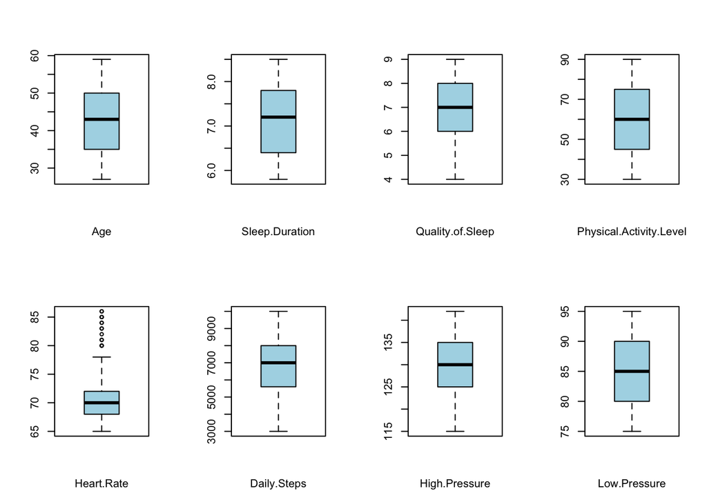

```r
par(mfrow=c(2,4))
boxplot(new_data$Age, col = "lightblue", xlab="Age")
boxplot(new_data$Sleep.Duration, col = "lightblue", xlab="Sleep.Duration")
boxplot(new_data$Quality.of.Sleep, col = "lightblue", xlab="Quality.of.Sleep")
boxplot(new_data$Physical.Activity.Level, col = "lightblue", xlab="Physical.Activity.Level")
boxplot(new_data$Heart.Rate, col = "lightblue", xlab="Heart.Rate")
boxplot(new_data$Daily.Steps, col = "lightblue", xlab="Daily.Steps")
boxplot(new_data$High.Pressure, col = "lightblue", xlab="High.Pressure")
boxplot(new_data$Low.Pressure, col = "lightblue", xlab="Low.Pressure")
```

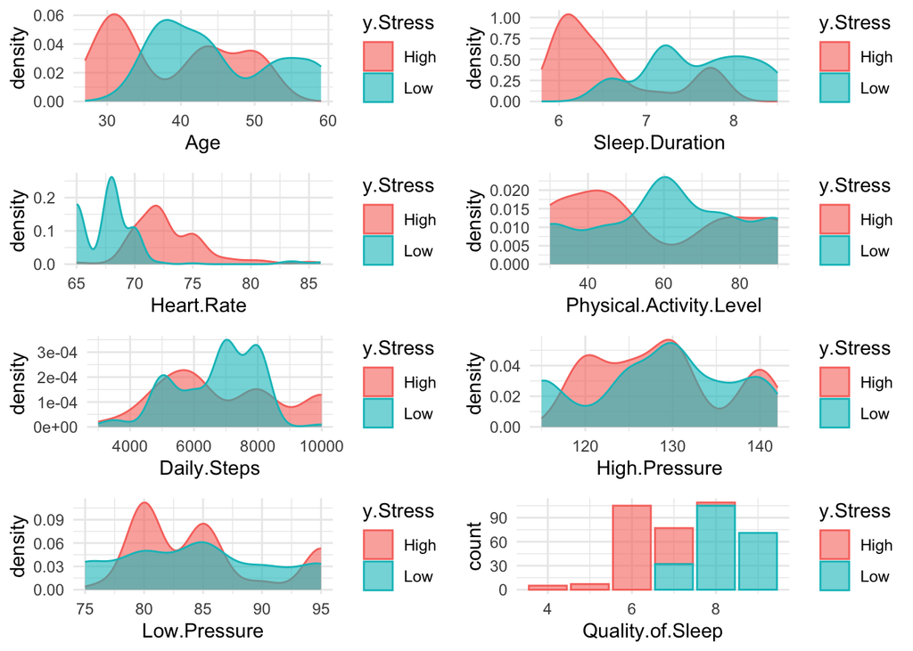

```r
plot1 <- ggplot(data = new_data, aes(x = Age, fill = y.Stress, color = y.Stress)) + geom_density(alpha = 0.6) + theme_minimal()
plot2 <- ggplot(data = new_data, aes(x = Sleep.Duration, fill = y.Stress, color = y.Stress)) + geom_density(alpha = 0.6) + theme_minimal()
plot3 <- ggplot(data = new_data, aes(x = Heart.Rate, fill = y.Stress, color = y.Stress)) + geom_density(alpha = 0.6) + theme_minimal()
plot4 <- ggplot(data = new_data, aes(x = Physical.Activity.Level, fill = y.Stress, color = y.Stress)) + geom_density(alpha = 0.6) + theme_minimal()
plot5 <- ggplot(data = new_data, aes(x = Daily.Steps, fill = y.Stress, color = y.Stress)) + geom_density(alpha = 0.6) + theme_minimal()
plot6 <- ggplot(data = new_data, aes(x = High.Pressure, fill = y.Stress, color = y.Stress)) + geom_density(alpha = 0.6) + theme_minimal()
plot7 <- ggplot(data = new_data, aes(x = Low.Pressure, fill = y.Stress, color = y.Stress)) + geom_density(alpha = 0.6) + theme_minimal()
plot8 <- ggplot(data = new_data, aes(x = Quality.of.Sleep, fill = y.Stress, color = y.Stress)) + geom_bar(alpha = 0.6) + theme_minimal()
grid.arrange(plot1, plot2, plot3, plot4, plot5, plot6, plot7,plot8, ncol = 2)
```

- Quality.of.Sleep 는 이산형 변수이므로, bar plot형태로 시각화하였습니다.
- Sleep.Duration, Quality.of.Sleep : 수면과 관련된 변수들의 경우, 값이 작을수록 y.Stress(스트레스 지수)가 높은 경우가 많고, 값이 클수록 y.Stress(스트레스 지수)가 낮은 경우가 많습니다.
- 따라서 스트레스 지수와 잠과 큰 연관이 있을 것으로 예상됩니다.
- Heart.Rate(심박수)의 경우 값 70을 경계로 y.Stress(스트레스 지수)의 분포가 변화하는데 전 연령의 평균 이상으로 건강한 심박수 66~69가 반영된 결과로 보입니다. 참고. https://ko.wikipedia.org/wiki/%EC%8B%AC%EB%B0%95%EC%88%98
- 다른 수치형 변수들도 y.Stress(스트레스 지수)에 따라 대체적으로 다른 분포를 보이고 있으나, 가장 큰 영향을 줄 것으로 보이는 변수는 Sleep.Duration, Quality.of.Sleep, Heart.Rate일 것으로 판단됩니다.

### 2.2 Categorical Data EDA

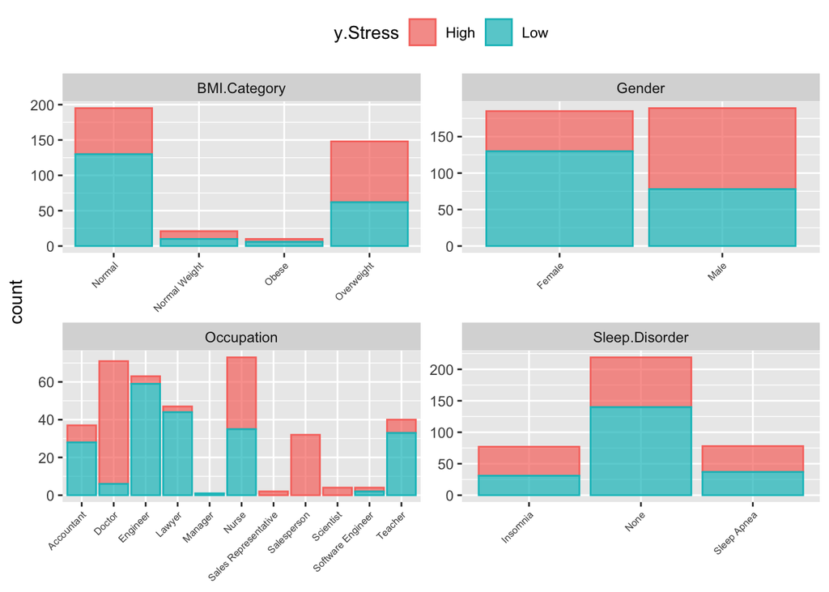

```r
new_data %>%
  select_if(is.factor) %>%
  gather(variable_name, value_name, -y.Stress) %>%
  ggplot(aes(x = value_name, fill = y.Stress, color = y.Stress)) +
  facet_wrap(~ variable_name, ncol = 2, scales = "free") +
  geom_bar(alpha = 0.7, position = "stack") +
  theme(axis.text.x = element_text(angle = 45, hjust = 1,size = 6),
        legend.position = "top",axis.title.x = element_blank())
```

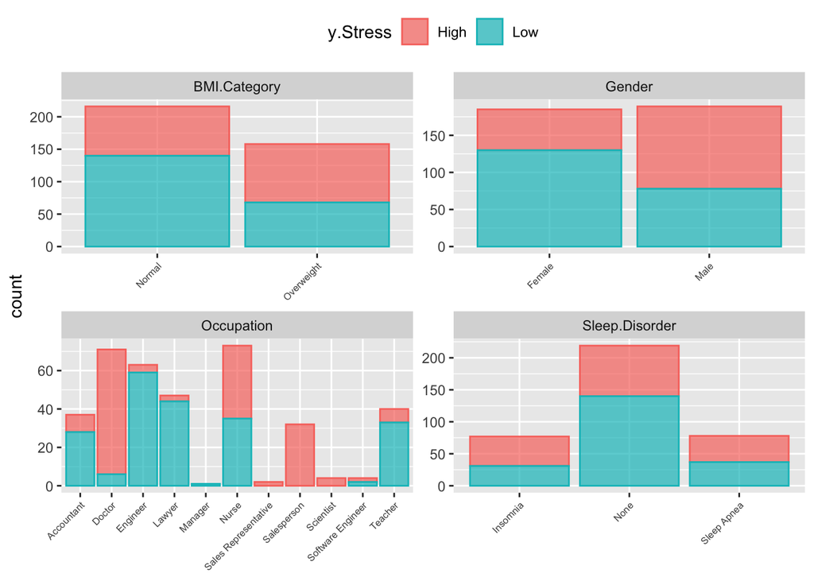

```r
new_data <- new_data %>%
  mutate(BMI.Category = factor(case_when(
    BMI.Category == "Normal Weight" ~ "Normal",
    BMI.Category == "Obese" ~ "Overweight",
    TRUE ~ as.character(BMI.Category)
  )))

new_data %>%
  select_if(is.factor) %>%
  gather(variable_name, value_name, -y.Stress) %>%
  ggplot(aes(x = value_name, fill = y.Stress, color = y.Stress)) +
  facet_wrap(~ variable_name, ncol = 2, scales = "free") +
  geom_bar(alpha = 0.7, position = "stack") +
  theme(axis.text.x = element_text(angle = 45, hjust = 1,size = 6),
        legend.position = "top",axis.title.x = element_blank())
```

- BMI Category 변수의 경우 4개의 범주로 구성되어 있는데 Normal Weight, Obese 범주의 데이터 수가 확연하게 작기 때문에 Normal Weight -> Normal, Obese -> Overweight로 2개의 범주로 BMI Category 변수 전처리를 진행하였습니다.
- 여자보다 남자가 스트레스 지수가 높은 경우가 많습니다. 이는 정말로 성별이 스트레스 지수에 영향이 있을수도 있으냐, 성별에 따라 특정 직업군의 쏠림으로 인한 영향일수도 있어 성별 별 직업 분포를 확인해보겠습니다.

```r
occupation_gen <- new_data %>% select(Occupation, Gender) %>% group_by(Gender, Occupation) %>% summarise(count = n())
```

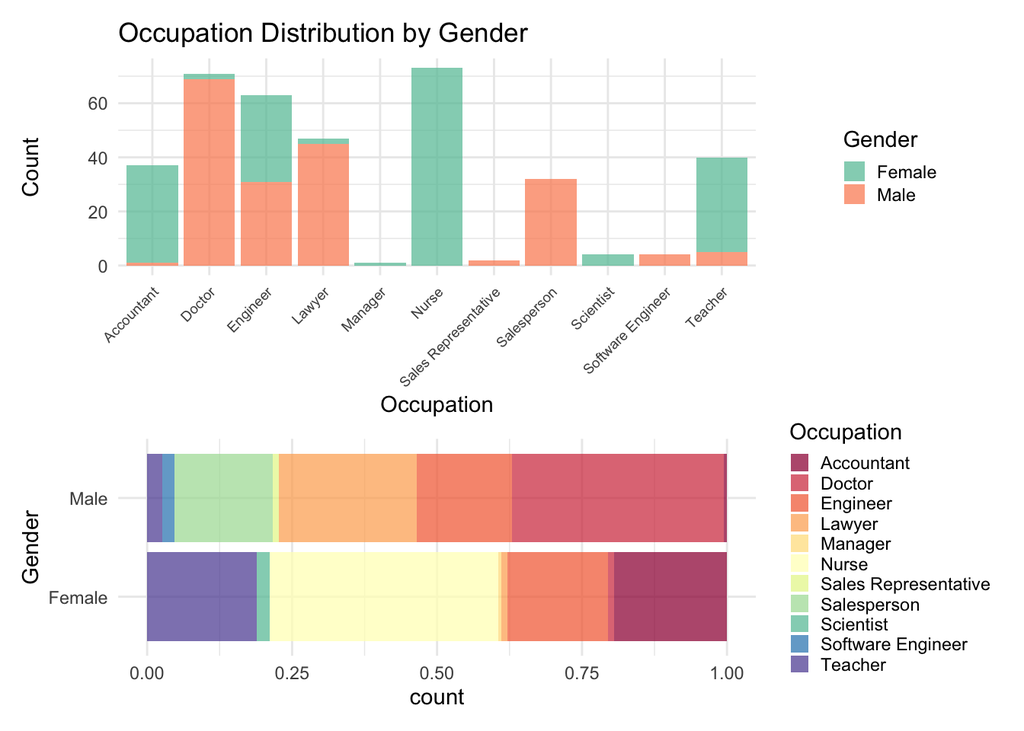

```r
p1 <- ggplot(occupation_gen, aes(x = Occupation, y = count, fill = Gender)) +
  geom_bar(stat = "identity", position = "stack",alpha = 0.73) +
  scale_fill_brewer(palette = "Set2") +
  labs(title = "Occupation Distribution by Gender", x = "Occupation", y = "Count", fill = "Gender") +
  theme_minimal() +theme(legend.key.size = unit(4, "mm")) + theme(axis.text.x = element_text(angle = 45, hjust = 1,size=7))

p2 <- ggplot(data = new_data) + geom_bar(mapping = aes(x=Gender, fill = Occupation), position = "fill", alpha =0.73) + coord_flip() + scale_fill_brewer(palette = 'Spectral') + theme_minimal() + theme(legend.key.size = unit(3.5, "mm"))

p1 / p2
```

- Gender가 y.Stress 즉 스트레스(High,Low) 의 정도에 영향을 줄 것이라고 가정 했을 때, Lawyer의 경우 남자임에도 불구하고 y.Stress가 낮음(Low)로 나타납니다. Nurse의 경우에도 대부분 여성인데 y.Stress가 높음(High)을 나타냅니다. 따라서 Occupation 변수가 y.Stress 에 더 직접적인 영향을 줄 것 이라 생각됩니다.

## 3. trainging set, Validation set 나누기

### 3.1 데이터 분할

```r
set.seed(123)

train_set <- new_data
train_idx <- sample(nrow(new_data), 0.7*nrow(new_data), replace=F)
train <- train_set[train_idx,]
validation <- train_set[-train_idx,]
```

### 3.2 표준화 set 생성

```r
scaled_train <- preProcess(train, method = c("center", "scale"))
scaled_validation <- preProcess(validation, method = c("center", "scale"))
scaled_train <- predict(scaled_train, train)
scaled_validation <- predict(scaled_validation, validation)
```

### H2O

```r
h2o.init(nthreads = -1)
```

```
##  Connection successful!
##
## R is connected to the H2O cluster:
##     H2O cluster uptime:         8 minutes 47 seconds
##     H2O cluster timezone:       Asia/Seoul
##     H2O data parsing timezone:  UTC
##     H2O cluster version:        3.42.0.2
##     H2O cluster version age:    4 months and 29 days
##     H2O cluster name:           H2O_started_from_R_xmink_gid159
##     H2O cluster total nodes:    1
##     H2O cluster total memory:   3.22 GB
##     H2O cluster total cores:    8
##     H2O cluster allowed cores:  8
##     H2O cluster healthy:        TRUE
##     H2O Connection ip:          localhost
##     H2O Connection port:        54321
##     H2O Connection proxy:       NA
##     H2O Internal Security:      FALSE
##     R Version:                  R version 4.3.1 (2023-06-16)
```

```r
h2o.no_progress()
```

### H2o에 Data load

```r
train.hex <- as.h2o(train, destination_frame = "train.hex")
validation.hex <- as.h2o(validation, destination_frame = "vaildation.hex")
scaled_train.hex <- as.h2o(scaled_train, destination_frame = "scaled_train.hex")
scaled_validation.hex <- as.h2o(scaled_validation, destination_frame = "scaled_validation.hex")
```

### 3.3 반응변수 종속변수 지정

```r
response_column <- "y.Stress"
predictors <- setdiff(names(train.hex), response_column)
```

## 4. Modeling

### 4.1 Random Foreset

```r
rf_model <- h2o.randomForest(x = predictors, y = response_column, training_frame = train.hex, seed=12345)
rf_perf <- h2o.performance(rf_model, validation.hex)
rf_perf
```

```
## H2OBinomialMetrics: drf
##
## MSE:  0.02801029
## RMSE:  0.1673628
## LogLoss:  0.08311131
## Mean Per-Class Error:  0.0177116
## AUC:  0.9987461
## AUCPR:  0.9987177
## Gini:  0.9974922
## R^2:  0.8878798
##
## Confusion Matrix (vertical: actual; across: predicted) for F1-optimal threshold:
##        High Low    Error    Rate
## High     57   1 0.017241   =1/58
## Low       1  54 0.018182   =1/55
## Totals   58  55 0.017699  =2/113
##
## Maximum Metrics: Maximum metrics at their respective thresholds
##                         metric threshold     value idx
## 1                       max f1  0.860000  0.981818   9
## 2                       max f2  0.776000  0.989209  11
## 3                 max f0point5  0.961771  0.992509   7
## 4                 max accuracy  0.961771  0.982301   7
## 5                max precision  0.999549  1.000000   0
## 6                   max recall  0.776000  1.000000  11
## 7              max specificity  0.999549  1.000000   0
## 8             max absolute_mcc  0.961771  0.965150   7
## 9   max min_per_class_accuracy  0.860000  0.981818   9
## 10 max mean_per_class_accuracy  0.860000  0.982288   9
## 11                     max tns  0.999549 58.000000   0
## 12                     max fns  0.999549 25.000000   0
## 13                     max fps  0.000000 58.000000  22
## 14                     max tps  0.776000 55.000000  11
## 15                     max tnr  0.999549  1.000000   0
## 16                     max fnr  0.999549  0.454545   0
## 17                     max fpr  0.000000  1.000000  22
## 18                     max tpr  0.776000  1.000000  11
##
## Gains/Lift Table: Extract with `h2o.gainsLift(<model>, <data>)` or `h2o.gainsLift(<model>, valid=<T/F>, xval=<T/F>)`
```

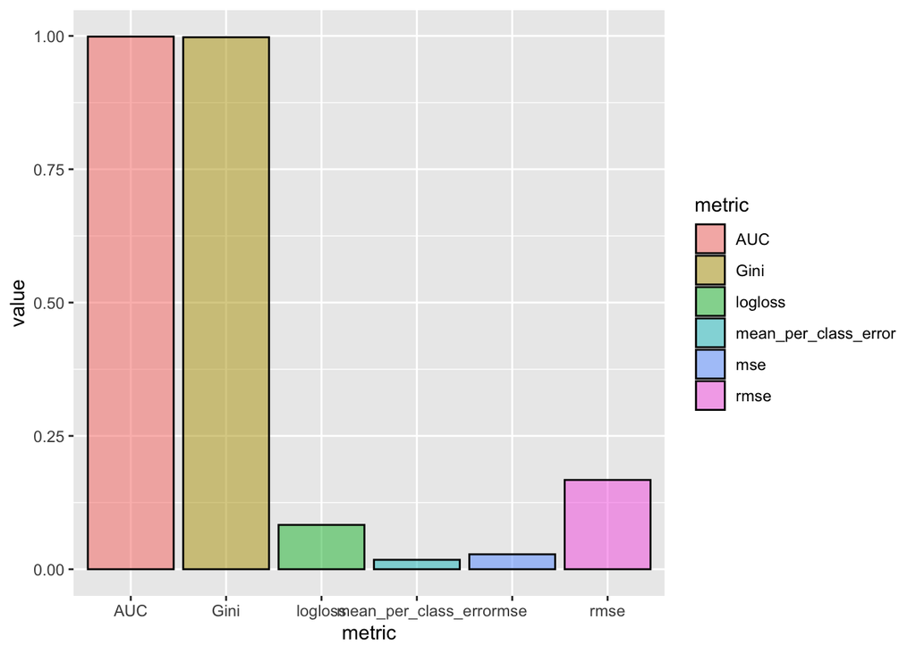

```r
perf <- h2o.performance(rf_model, validation.hex)

mse <- perf@metrics$MSE
rmse <- perf@metrics$RMSE
logloss <- perf@metrics$logloss
mean_per_class_error <- perf@metrics$mean_per_class_error
AUC <- perf@metrics$AUC
Gini <- perf@metrics$Gini

output <- data.frame(mse, rmse, logloss, mean_per_class_error, AUC, Gini) %>% tidyr::gather("metric", "value")

ggplot(output, aes(metric, value, fill = metric)) +
  geom_bar(stat = "identity", color = "black", alpha = 0.5)
```

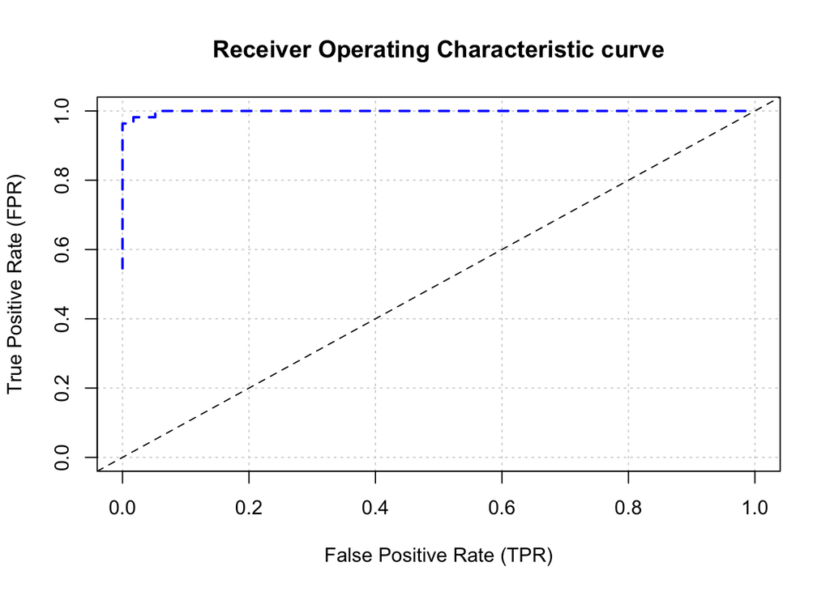

```r
plot(perf, colorize = TRUE)
```

### 4.2 Logistic Regression

```r
glm_model <- h2o.glm(x = predictors, y = response_column, training_frame = scaled_train.hex, seed=12345)
glm_perf <- h2o.performance(glm_model, scaled_validation.hex)
glm_perf
```

```
## H2OBinomialMetrics: glm
##
## MSE:  0.09850233
## RMSE:  0.3138508
## LogLoss:  0.3288027
## Mean Per-Class Error:  0.05266458
## AUC:  0.9761755
## AUCPR:  0.9776732
## Gini:  0.9523511
## R^2:  0.6057128
## Residual Deviance:  74.30942
## AIC:  86.30942
##
## Confusion Matrix (vertical: actual; across: predicted) for F1-optimal threshold:
##        High Low    Error    Rate
## High     54   4 0.068966   =4/58
## Low       2  53 0.036364   =2/55
## Totals   56  57 0.053097  =6/113
##
## Maximum Metrics: Maximum metrics at their respective thresholds
##                         metric threshold     value idx
## 1                       max f1  0.689426  0.946429  32
## 2                       max f2  0.689426  0.956679  32
## 3                 max f0point5  0.835750  0.952381  24
## 4                 max accuracy  0.689426  0.946903  32
## 5                max precision  0.974858  1.000000   0
## 6                   max recall  0.292681  1.000000  46
## 7              max specificity  0.974858  1.000000   0
## 8             max absolute_mcc  0.689426  0.894391  32
## 9   max min_per_class_accuracy  0.692025  0.931034  31
## 10 max mean_per_class_accuracy  0.689426  0.947335  32
## 11                     max tns  0.974858 58.000000   0
## 12                     max fns  0.974858 53.000000   0
## 13                     max fps  0.006810 58.000000  68
## 14                     max tps  0.292681 55.000000  46
## 15                     max tnr  0.974858  1.000000   0
## 16                     max fnr  0.974858  0.963636   0
## 17                     max fpr  0.006810  1.000000  68
## 18                     max tpr  0.292681  1.000000  46
##
## Gains/Lift Table: Extract with `h2o.gainsLift(<model>, <data>)` or `h2o.gainsLift(<model>, valid=<T/F>, xval=<T/F>)`
```

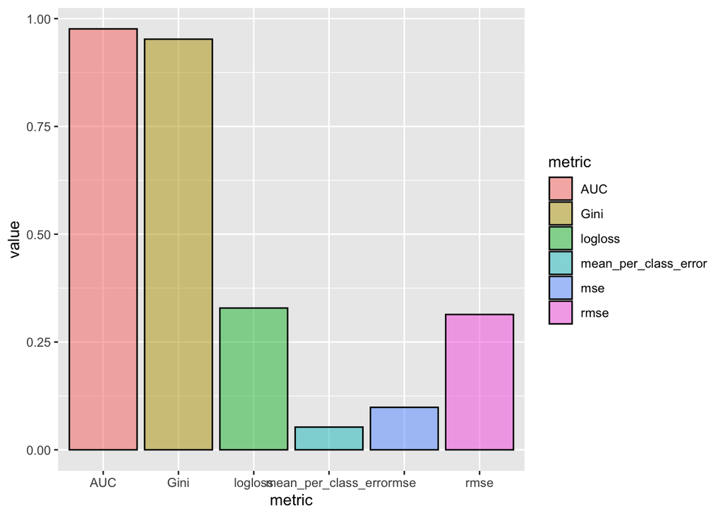

```r
perf <- h2o.performance(glm_model, scaled_validation.hex)

mse <- perf@metrics$MSE
rmse <- perf@metrics$RMSE
logloss <- perf@metrics$logloss
mean_per_class_error <- perf@metrics$mean_per_class_error
AUC <- perf@metrics$AUC
Gini <- perf@metrics$Gini

output <- data.frame(mse, rmse, logloss, mean_per_class_error, AUC, Gini) %>% tidyr::gather("metric", "value")

ggplot(output, aes(metric, value, fill = metric)) +
  geom_bar(stat = "identity", color = "black", alpha = 0.5)
```

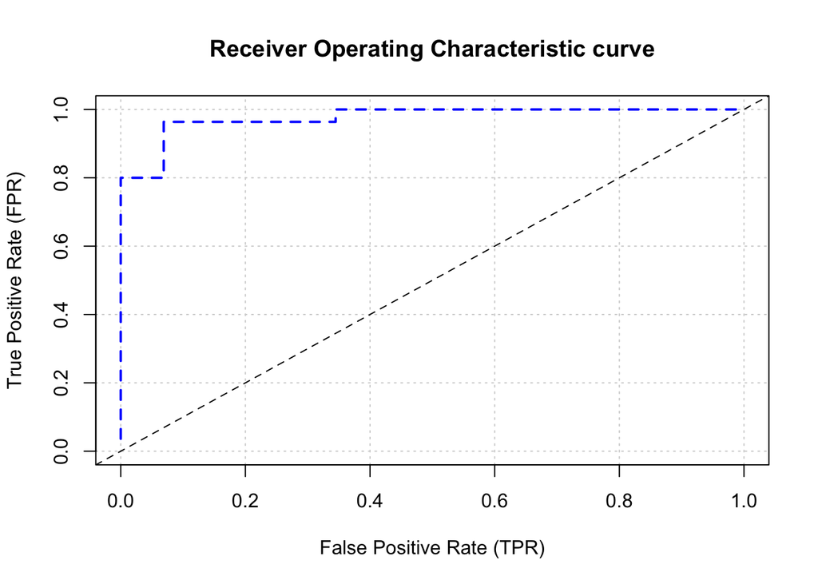

```r
plot(perf, colorize = TRUE)
```

### 4.3 GBM

```r
gbm_model <- h2o.gbm(x = predictors, y = response_column, training_frame = train.hex, seed=12345)
gbm_perf <-h2o.performance(gbm_model, validation.hex)
gbm_perf
```

```
## H2OBinomialMetrics: gbm
##
## MSE:  0.03136752
## RMSE:  0.1771088
## LogLoss:  0.1192907
## Mean Per-Class Error:  0.0177116
## AUC:  0.9909091
## AUCPR:  0.9874143
## Gini:  0.9818182
## R^2:  0.8744414
##
## Confusion Matrix (vertical: actual; across: predicted) for F1-optimal threshold:
##        High Low    Error    Rate
## High     57   1 0.017241   =1/58
## Low       1  54 0.018182   =1/55
## Totals   58  55 0.017699  =2/113
##
## Maximum Metrics: Maximum metrics at their respective thresholds
##                         metric threshold     value idx
## 1                       max f1  0.945861  0.981818  27
## 2                       max f2  0.910219  0.989209  29
## 3                 max f0point5  0.945861  0.981818  27
## 4                 max accuracy  0.945861  0.982301  27
## 5                max precision  0.997696  1.000000   0
## 6                   max recall  0.910219  1.000000  29
## 7              max specificity  0.997696  1.000000   0
## 8             max absolute_mcc  0.945861  0.964577  27
## 9   max min_per_class_accuracy  0.945861  0.981818  27
## 10 max mean_per_class_accuracy  0.945861  0.982288  27
## 11                     max tns  0.997696 58.000000   0
## 12                     max fns  0.997696 54.000000   0
## 13                     max fps  0.001593 58.000000  59
## 14                     max tps  0.910219 55.000000  29
## 15                     max tnr  0.997696  1.000000   0
## 16                     max fnr  0.997696  0.981818   0
## 17                     max fpr  0.001593  1.000000  59
## 18                     max tpr  0.910219  1.000000  29
##
## Gains/Lift Table: Extract with `h2o.gainsLift(<model>, <data>)` or `h2o.gainsLift(<model>, valid=<T/F>, xval=<T/F>)`
```

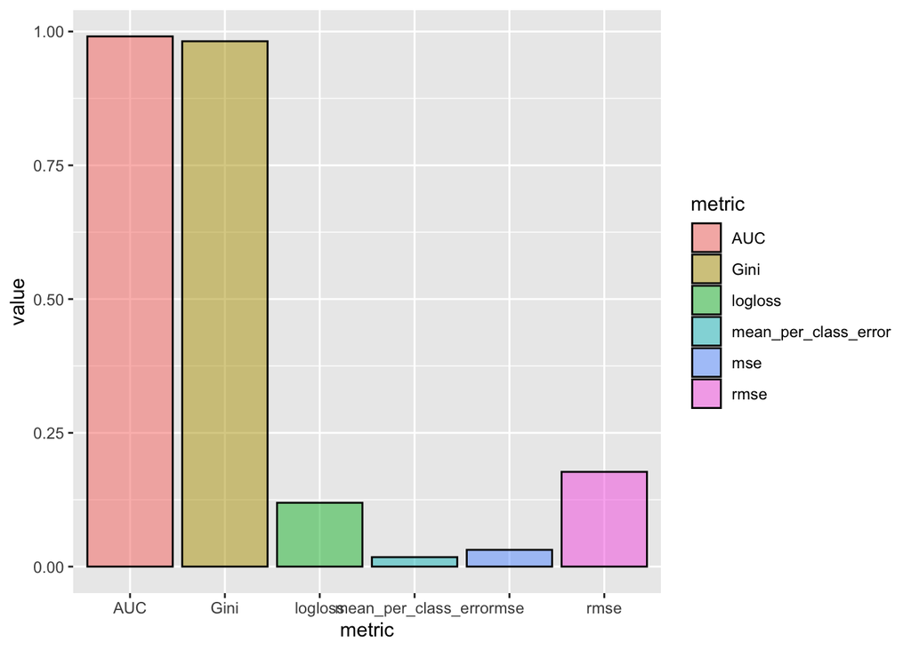

```r
perf <- h2o.performance(gbm_model, validation.hex)

mse <- perf@metrics$MSE
rmse <- perf@metrics$RMSE
logloss <- perf@metrics$logloss
mean_per_class_error <- perf@metrics$mean_per_class_error
AUC <- perf@metrics$AUC
Gini <- perf@metrics$Gini

output <- data.frame(mse, rmse, logloss, mean_per_class_error, AUC, Gini) %>% tidyr::gather("metric", "value")

ggplot(output, aes(metric, value, fill = metric)) +
  geom_bar(stat = "identity", color = "black", alpha = 0.5)
```

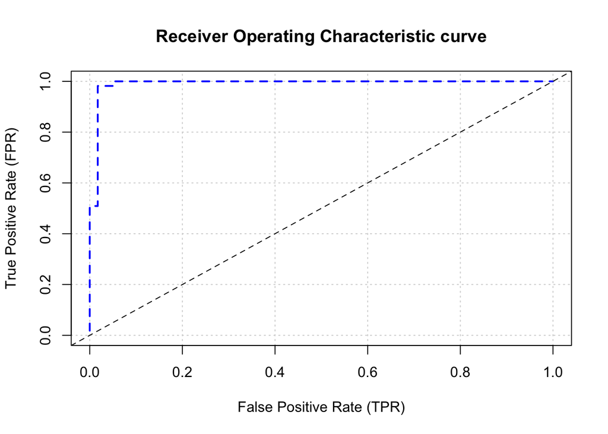

```r
plot(perf, colorize = TRUE)
```

### 4.4 Deep learning

```r
deeplearning_model <- h2o.deeplearning(x = predictors, y = response_column, training_frame = train.hex, seed=12345)
deep_perf<- h2o.performance(deeplearning_model, validation.hex)
deep_perf
```

```
## H2OBinomialMetrics: deeplearning
##
## MSE:  0.04673845
## RMSE:  0.2161908
## LogLoss:  0.2383659
## Mean Per-Class Error:  0.0177116
## AUC:  0.9887147
## AUCPR:  0.9838612
## Gini:  0.9774295
##
## Confusion Matrix (vertical: actual; across: predicted) for F1-optimal threshold:
##        High Low    Error    Rate
## High     57   1 0.017241   =1/58
## Low       1  54 0.018182   =1/55
## Totals   58  55 0.017699  =2/113
##
## Maximum Metrics: Maximum metrics at their respective thresholds
##                         metric threshold     value idx
## 1                       max f1  0.991446  0.981818  28
## 2                       max f2  0.991446  0.981818  28
## 3                 max f0point5  0.991446  0.981818  28
## 4                 max accuracy  0.991446  0.982301  28
## 5                max precision  1.000000  1.000000   0
## 6                   max recall  0.823202  1.000000  33
## 7              max specificity  1.000000  1.000000   0
## 8             max absolute_mcc  0.991446  0.964577  28
## 9   max min_per_class_accuracy  0.991446  0.981818  28
## 10 max mean_per_class_accuracy  0.991446  0.982288  28
## 11                     max tns  1.000000 58.000000   0
## 12                     max fns  1.000000 45.000000   0
## 13                     max fps  0.000000 58.000000  69
## 14                     max tps  0.823202 55.000000  33
## 15                     max tnr  1.000000  1.000000   0
## 16                     max fnr  1.000000  0.818182   0
## 17                     max fpr  0.000000  1.000000  69
## 18                     max tpr  0.823202  1.000000  33
##
## Gains/Lift Table: Extract with `h2o.gainsLift(<model>, <data>)` or `h2o.gainsLift(<model>, valid=<T/F>, xval=<T/F>)`
```

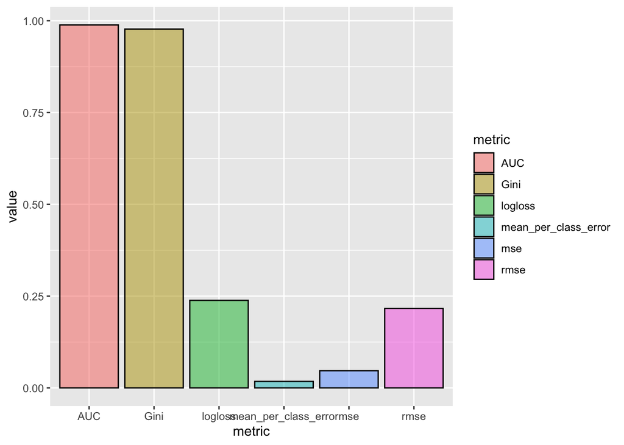

```r
perf <- h2o.performance(deeplearning_model, validation.hex)

mse <- perf@metrics$MSE
rmse <- perf@metrics$RMSE
logloss <- perf@metrics$logloss
mean_per_class_error <- perf@metrics$mean_per_class_error
AUC <- perf@metrics$AUC
Gini <- perf@metrics$Gini

output <- data.frame(mse, rmse, logloss, mean_per_class_error, AUC, Gini) %>% tidyr::gather("metric", "value")

ggplot(output, aes(metric, value, fill = metric)) +
  geom_bar(stat = "identity", color = "black", alpha = 0.5)
```

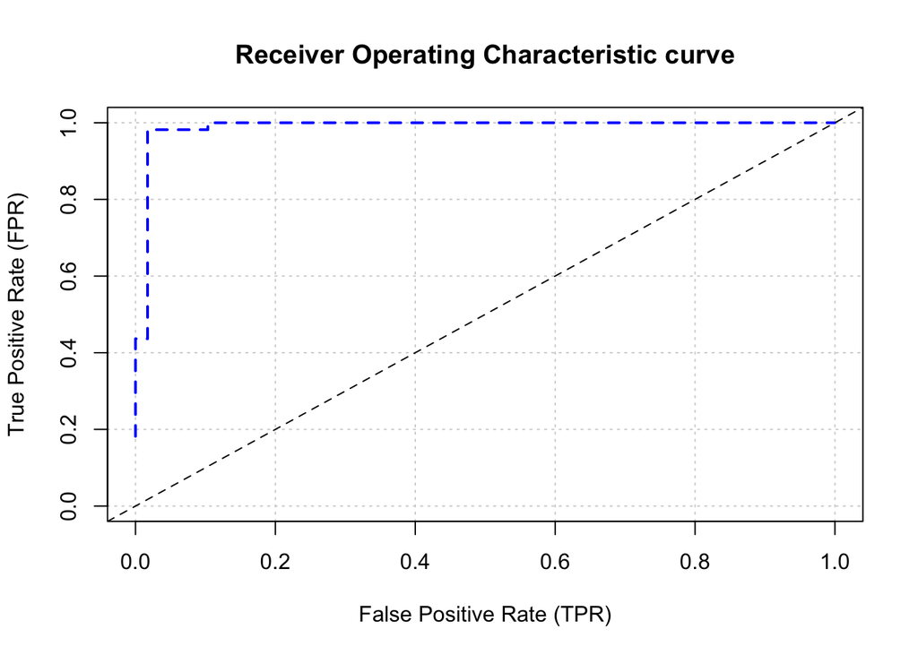

```r
plot(perf, colorize = TRUE)
```

### 4.5 모델 별 비교

4가지 모델 별 performance를 서로의 단점을 보완해줄 수 있는 3가지 평가 지표 F1 score, Accuracy, AUC을 확인해보면 다음과 같습니다.

[figure not shown]

- 모델링 별 importance of variable 확인

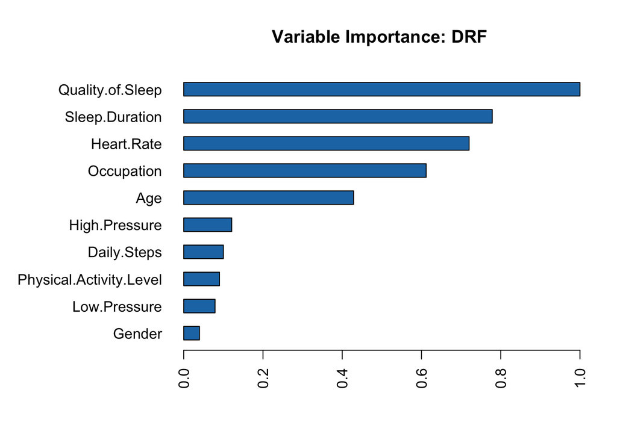

```r
h2o.varimp_plot(rf_model)
```

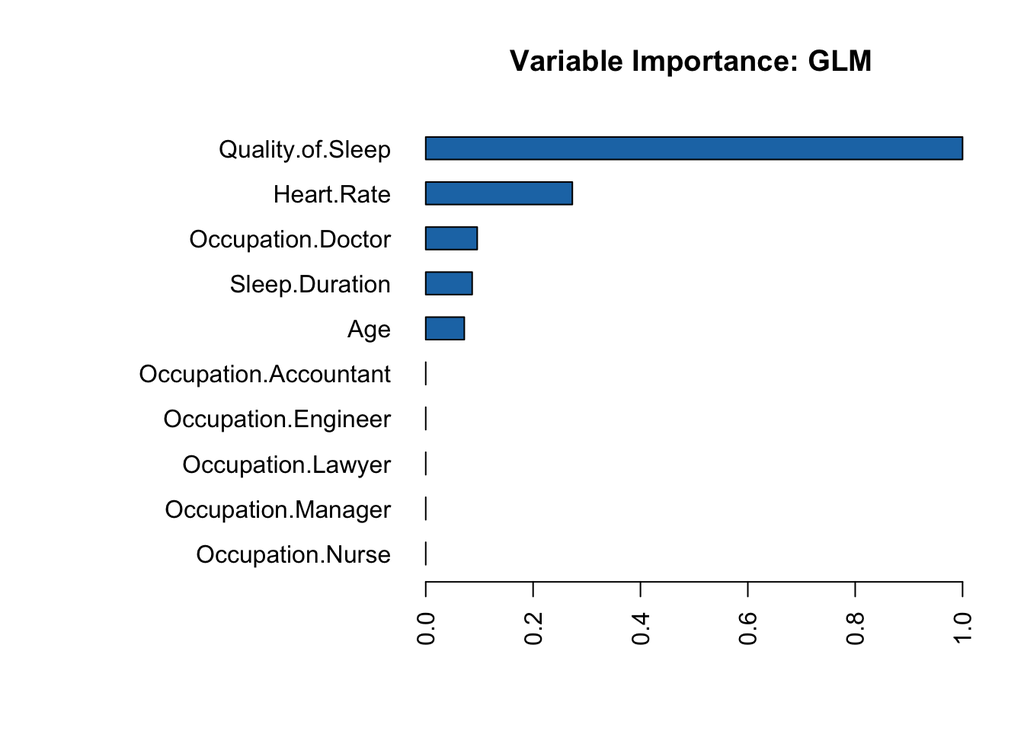

```r
h2o.varimp_plot(glm_model)
```

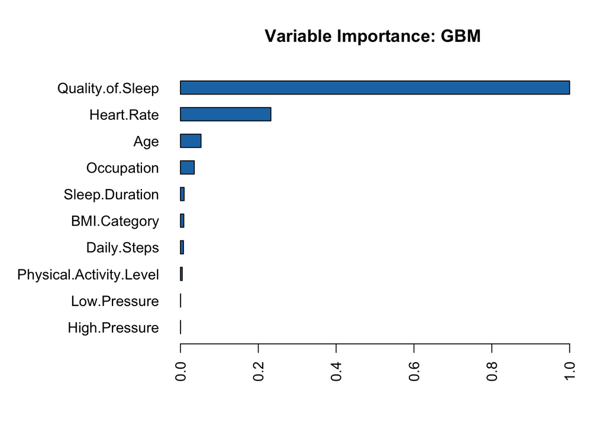

```r
h2o.varimp_plot(gbm_model)
```

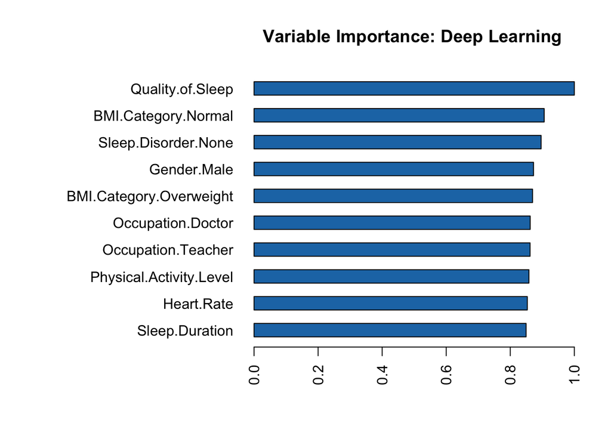

```r
h2o.varimp_plot(deeplearning_model)
```

## 5. 로직스틱 기반 평점표 만들기

### 5.1 더미변수화

- 범주화
  - Quality.of.Sleep : 6이하, 7, 7초과
  - Heart.Rate : 67이하, 68이상 72이하, 72 초과
  - Sleep.Duration : 6.5시간 미만, 6.5시간 이상 ~ 8시간 미만, 8시간 이상
  - Age : (20,30대),40대,50대
  - Occupation : 유일하게 범주형 변수로 따로 더미변수화를 진행하지 않았습니다.
- 이유:
  - Quality.of.Sleep : 2.1 에서 밀도그래프로 시각화한 부분을 참고하여 6 이하인 경우 모두 높은 스트레스 지수를 보이고 7인 경우 높은 경우와 낮은 경우가 반반이었으며 8 이상인 경우 거의 대부분 낮은 스트레스 지수를 보인 점을 고려하여 더미변수화를 진행하였습니다.
  - Heart.Rate : 2.1 에서 밀도그래프로 시각화한 부분을 참고하여 67 이하인 경우 모두 낮은 스트레스 지, 72 초과인 경우 높은 스트레스 지수, 그 사이에서는 낮고 높은 스트레스 지수가 반반 나타나는 점을 고려하여 더미변수화를 진행하였습니다.
  - Sleep.Duration : https://www.sleepmed.or.kr/content/info/sleeptime.html 대한수면학회의 적정 수면시간과 수면 사이클이 90분의 배수로 진행된다는 점을 참고하여 6시간 30분 ~ 8시간 정도가 적정 수면시간이라 생각하여 나눴습니다.
  - Age : 1.2에서 데이터 summary를 보았을 때 20대는 최소가 27세 이고 20대 데이터 수도 적어 30대로 추가해서 20,30대를 묶고, 나머지는 40대,50대로 나눴습니다. (27세가 최소값, 59세가 최대값)
  - Occupation : 유일하게 범주형 변수로 따로 더미변수화를 진행하지 않았습니다.

```r
new_data.Quality.of.Sleep <- new_data$Quality.of.Sleep
Quality.of.Sleep.under6 <- (new_data.Quality.of.Sleep <= 6 )*1
Quality.of.Sleep7 <- (new_data.Quality.of.Sleep == 7)*1

Quality.of.Sleep.dummy <- cbind(Quality.of.Sleep.under6 , Quality.of.Sleep7)
head(Quality.of.Sleep.dummy)
```

```
##      Quality.of.Sleep.under6 Quality.of.Sleep7
## [1,]                       1                 0
## [2,]                       1                 0
## [3,]                       1                 0
## [4,]                       1                 0
## [5,]                       1                 0
## [6,]                       1                 0
```

```r
new_data.Heart.Rate <- new_data$Heart.Rate
Heart.Rate.under67 <- (new_data.Heart.Rate <= 67 ) *1
Heart.Rate.over72 <- (new_data.Heart.Rate > 72 ) *1

Heart.Rate.dummy <- cbind(Heart.Rate.under67 , Heart.Rate.over72)
head(Heart.Rate.dummy)
```

```
##      Heart.Rate.under67 Heart.Rate.over72
## [1,]                  0                 1
## [2,]                  0                 1
## [3,]                  0                 1
## [4,]                  0                 1
## [5,]                  0                 1
## [6,]                  0                 1
```

```r
new_data.Sleep.Duration <- new_data$Sleep.Duration
Sleep.Duration.under6.5 <- (new_data.Sleep.Duration < 6.5 )*1
Sleep.Duration.over8 <- (new_data.Sleep.Duration >= 8 )*1

Sleep.Duration.dummy <- cbind(Sleep.Duration.under6.5 , Sleep.Duration.over8)
head(Sleep.Duration.dummy)
```

```
##      Sleep.Duration.under6.5 Sleep.Duration.over8
## [1,]                       1                    0
## [2,]                       1                    0
## [3,]                       1                    0
## [4,]                       1                    0
## [5,]                       1                    0
## [6,]                       1                    0
```

```r
new_data.Age <- new_data$Age
Age.20s.30s <- (new_data.Age <= 39 ) *1
Age.50s <- ( new_data.Age >= 50 ) *1

Age.dummy <- cbind(Age.20s.30s, Age.50s)
head(Age.dummy)
```

```
##      Age.20s.30s Age.50s
## [1,]           1       0
## [2,]           1       0
## [3,]           1       0
## [4,]           1       0
## [5,]           1       0
## [6,]           1       0
```

```r
new_data.cp <- cbind(new_data,Quality.of.Sleep.dummy,Heart.Rate.dummy,Sleep.Duration.dummy,Age.dummy)
```

### 5.2 scorig을 위한 logistic regression

```r
logit.new_data.cp <- glm(y.Stress ~ Quality.of.Sleep.under6 + Quality.of.Sleep7 + Heart.Rate.under67 + Heart.Rate.over72 + Sleep.Duration.under6.5 + Sleep.Duration.over8 + Age.20s.30s + Age.50s + Occupation, data = new_data.cp[train_idx,], family=binomial())
logit.new_data.cp
```

```
##
## Call:  glm(formula = y.Stress ~ Quality.of.Sleep.under6 + Quality.of.Sleep7 +
##     Heart.Rate.under67 + Heart.Rate.over72 + Sleep.Duration.under6.5 +
##     Sleep.Duration.over8 + Age.20s.30s + Age.50s + Occupation,
##     family = binomial(), data = new_data.cp[train_idx, ])
##
## Coefficients:
##                    (Intercept)         Quality.of.Sleep.under6
##                         -4.442                        -136.561
##              Quality.of.Sleep7              Heart.Rate.under67
##                        -43.862                         -10.031
##              Heart.Rate.over72         Sleep.Duration.under6.5
##                         50.621                           1.984
##           Sleep.Duration.over8                     Age.20s.30s
##                         27.859                           7.150
##                        Age.50s                OccupationDoctor
##                        -10.391                          18.493
##             OccupationEngineer                OccupationLawyer
##                         29.610                          27.281
##              OccupationManager                 OccupationNurse
##                         22.249                          53.254
## OccupationSales Representative           OccupationSalesperson
##                         56.682                         115.110
##            OccupationScientist     OccupationSoftware Engineer
##                         56.682                          23.011
##              OccupationTeacher
##                         61.108
##
## Degrees of Freedom: 260 Total (i.e. Null);  242 Residual
## Null Deviance:       354
## Residual Deviance: 15.09     AIC: 53.09
```

```r
new_data.val <- predict(logit.new_data.cp, newdata=new_data.cp[-train_idx, ])
new_data.val[1:10]
```

```
##          3          6          8         12         15         17         18
##  -62.75508  -58.23755  -22.66121  -22.66121 -113.37605  -29.97767 -113.37605
##         19         21         28
##  -29.97767  -22.66121  -22.66121
```

```r
score.val <- data.frame(log.odds=new_data.val, High.Low=new_data.cp[-train_idx, "y.Stress"])
score.val[1:10,]
```

```
##      log.odds High.Low
## 3   -62.75508     High
## 6   -58.23755     High
## 8   -22.66121     High
## 12  -22.66121     High
## 15 -113.37605     High
## 17  -29.97767     High
## 18 -113.37605     High
## 19  -29.97767     High
## 21  -22.66121     High
## 28  -22.66121     High
```

### 5.3 scorecard (평점표)

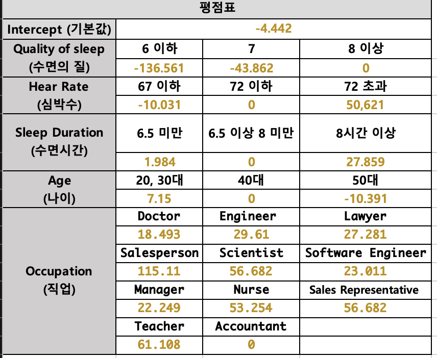